# Oly-Genetics-NF-Testing

Laura H Spencer

January 17, 2018

## Oly Genetics Analysis, playing around with data

My github repo: https://github.com/laurahspencer/O.lurida_genetics

```r
# Import 2016/2017 microsatellite data
# Used the following reference: https://grunwaldlab.github.io/Population_Genetics_in_R/TOC.html

NFH.2016 <- read.genalex("Data/Oly2016NFH_Rounded.csv", ploidy=2) #read
NFW.2017 <- read.genalex("Data/Oly2017NFW_Rounded.csv", ploidy=2)
NF <- read.genalex("Data/Oly2016NFH+2017NFW_Merged.csv", ploidy=2)
summary(NFH.2016)
```

```
##
## // Number of individuals: 100
## // Group sizes: 100
## // Number of alleles per locus: 31 14 14 17 18 18
## // Number of alleles per group: 112
## // Percentage of missing data: 3 %
## // Observed heterozygosity: 0.93 0.71 0.95 0.94 0.94 0.93
## // Expected heterozygosity: 0.94 0.75 0.86 0.92 0.92 0.92
```

```r
summary(NFW.2017) #summary of wild samples
```

```
##
## // Number of individuals: 99
## // Group sizes: 99
## // Number of alleles per locus: 30 13 15 19 20 19
## // Number of alleles per group: 116
## // Percentage of missing data: 1.85 %
## // Observed heterozygosity: 0.98 0.71 0.88 0.93 0.94 0.93
## // Expected heterozygosity: 0.94 0.74 0.87 0.93 0.93 0.93
```

```r
summary(NF) #summary of hatchery and wild combined
```

```
##
## // Number of individuals: 199
## // Group sizes: 99 100
## // Number of alleles per locus: 34 15 17 19 20 19
## // Number of alleles per group: 116 112
## // Percentage of missing data: 2.43 %
## // Observed heterozygosity: 0.95 0.71 0.91 0.93 0.94 0.93
## // Expected heterozygosity: 0.95 0.75 0.87 0.93 0.93 0.93
```

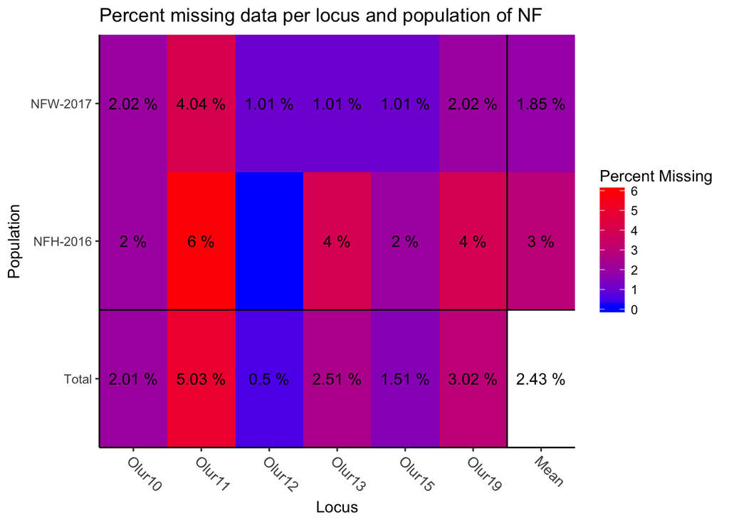

```
##           Locus
## Population Olur10 Olur11 Olur12 Olur13 Olur15 Olur19  Mean
##   NFW-2017  0.020  0.040  0.010  0.010  0.010  0.020 0.019
##   NFH-2016  0.020  0.060      .  0.040  0.020  0.040 0.030
##   Total     0.020  0.050  0.005  0.025  0.015  0.030 0.024
```

```r
info_table(NF, type="missing", plot=TRUE) #see how the missing data is distributed over the 2 populations
```

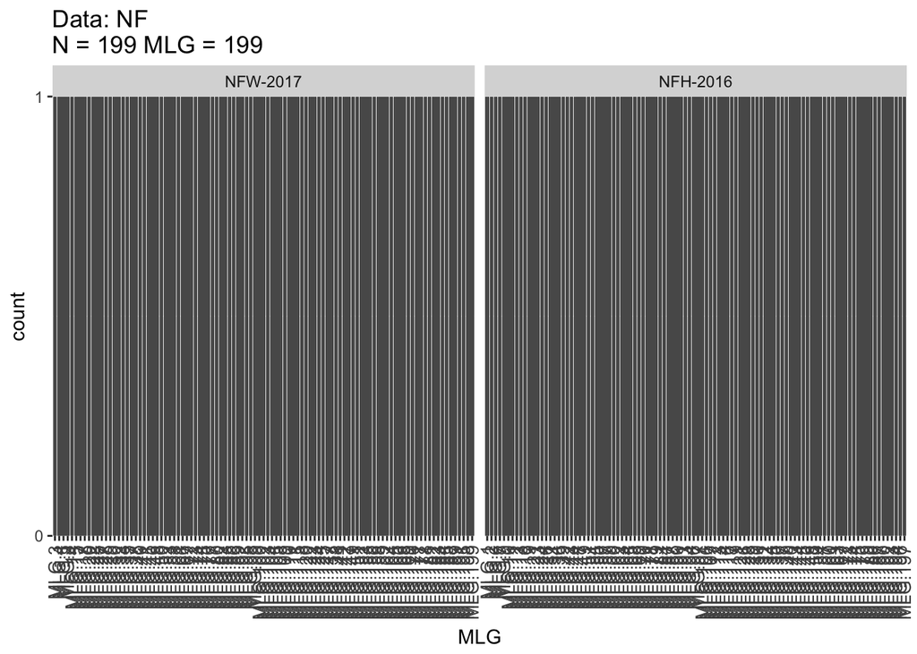

[output not shown]

[output cut: 17 more lines]

```
##          MLG.165 MLG.166 MLG.167 MLG.168 MLG.169 MLG.170 MLG.171 MLG.172
## NFW-2017       1       1       0       1       1       1       1       0
## NFH-2016       0       0       1       0       0       0       0       1
##          MLG.173 MLG.174 MLG.175 MLG.176 MLG.177 MLG.178 MLG.179 MLG.180
## NFW-2017       0       0       0       0       1       1       0       0
## NFH-2016       1       1       1       1       0       0       1       1
##          MLG.181 MLG.182 MLG.183 MLG.184 MLG.185 MLG.186 MLG.187 MLG.188
## NFW-2017       1       1       1       1       1       0       0       1
## NFH-2016       0       0       0       0       0       1       1       0
##          MLG.189 MLG.190 MLG.191 MLG.192 MLG.193 MLG.194 MLG.195 MLG.196
## NFW-2017       1       0       1       0       0       0       1       0
## NFH-2016       0       1       0       1       1       1       0       1
##          MLG.197 MLG.198 MLG.199
## NFW-2017       0       1       1
## NFH-2016       1       0       0
```

```r
mlg.table(NF) #genotype eveness. Result is N=199; MLG=199
```

## Generate more summary statistics using `poppr` function

Abbreviations used in t Statistic  
* Pop: Population name.  
* N: Number of individuals observed.  
* MLG: Number of multilocus genotypes (MLG) observed.  
* eMLG: The number of expected MLG at the smallest sample size ≥ 10 based on rarefaction  
* SE: Standard error based on eMLG.  
* H: Shannon-Wiener Index of MLG diversity (Shannon, 2001).  
* G: Stoddart and Taylor’s Index of MLG diversity (Stoddart & Taylor, 1988).  
* lambda: Simpson’s Index (Simpson, 1949). 0 = no genotypes are differet; 1 = all genotypes are different  
* E.5: Evenness, E5E5 (Pielou, 1975; Ludwig & Reynolds, 1988; Grünwald et al., 2003).  
* Hexp: Nei’s unbiased gene diversity (Nei, 1978).  
* Ia: The index of association, IAIA (Brown, Feldman & Nevo, 1980; Smith et al., 1993).  
* rbarD: The standardized index of association, r¯dr¯d [@].

```r
NF.pop <- poppr(NF) #summary stats on each population
NF.pop
```

```
##        Pop   N MLG eMLG       SE    H   G lambda E.5  Hexp    Ia rbarD
## 1 NFW-2017  99  99   99 0.00e+00 4.60  99  0.990   1 0.894 0.611 0.124
## 2 NFH-2016 100 100   99 2.58e-08 4.61 100  0.990   1 0.891 0.590 0.120
## 3    Total 199 199   99 0.00e+00 5.29 199  0.995   1 0.893 0.605 0.122
##   File
## 1   NF
## 2   NF
## 3   NF
```

```r
(NF.pop$N / (NF.pop$N - 1)) * NF.pop$lambda #corrected simpson's index (N/(N-1)) #all different genotypes
```

```
## [1] 1 1 1
```

## Are our populations in Hardy-Weinberg equilibrium?

Hardy‐Weinberg Assumptions include: • infinite population • discrete generations • random mating • no selection • no migration in or out of population • no mutation • equal initial genotype frequencies in the two sexes Equilibrium is reached after one generation of mating under the Hardy‐Weinberg assumptions…Genotype frequencies remain the same from generation to generation.

```r
library("pegas")
NF.HW <- seppop(NF) %>% lapply(hw.test, B=1000) #all P-values >0.05; reject the null that these populations are under HWE
NF.HW
```

```
## $`NFW-2017`
##            chi^2  df Pr(chi^2 >) Pr.exact
## Olur10 447.58545 435   0.3280911    0.285
## Olur11  48.88706  78   0.9959968    0.789
## Olur12  70.89750 105   0.9956481    0.918
## Olur13 166.41974 171   0.5846400    0.319
## Olur15 191.69997 190   0.4517938    0.315
## Olur19 165.39521 171   0.6065314    0.325
##
## $`NFH-2016`
##            chi^2  df Pr(chi^2 >) Pr.exact
## Olur10 417.06735 465   0.9459973    0.615
## Olur11  58.00523  91   0.9972368    0.806
## Olur12  67.18583  91   0.9711158    0.822
## Olur13 137.46193 136   0.4487866    0.130
## Olur15 159.88890 153   0.3350415    0.085
## Olur19 159.56688 153   0.3415811    0.101
```

```r
NF.HW.P <- sapply(NF.HW, "[", i=TRUE, j=3) #pvalues of HW chi-squared test for all loci, both pops combined into a dataframe
NF.HW.P
```

```
##         NFW-2017  NFH-2016
## Olur10 0.3280911 0.9459973
## Olur11 0.9959968 0.9972368
## Olur12 0.9956481 0.9711158
## Olur13 0.5846400 0.4487866
## Olur15 0.4517938 0.3350415
## Olur19 0.6065314 0.3415811
```

# Are populations in linkage disequilibrium?

Test the null hypothesis that alleles observed at different loci are not linked. This is the case if populations are sexual while alleles recombine freely into new genotypes during the process of sexual reproduction: IA =VO/VE -1 … where V0 is the observed variance of K and VE is the expected variance of K, where K is the number of loci at which two individuals differ.

```r
library("magrittr")
NF.ia.H <- ia(popsub(NF, "NFH-2016"), sample=999)
```

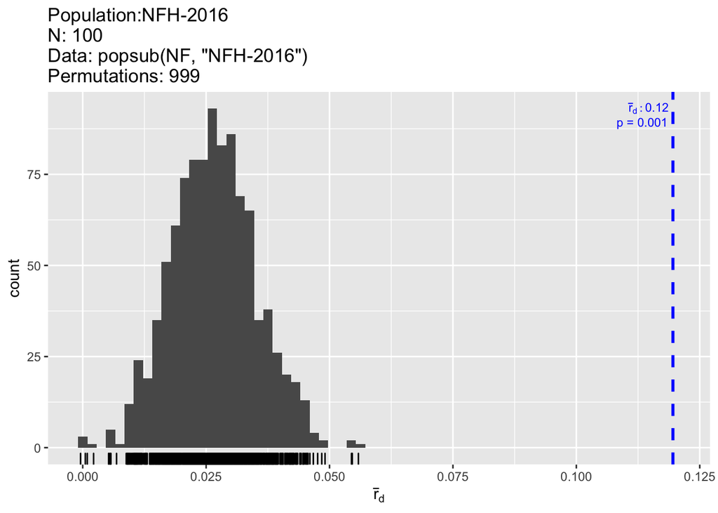

```r
NF.ia.H
```

```
##        Ia      p.Ia     rbarD      p.rD
## 0.5900609 0.0010000 0.1195621 0.0010000
```

```r
NF.ia.W <- ia(popsub(NF, "NFW-2017"), sample=999)
```

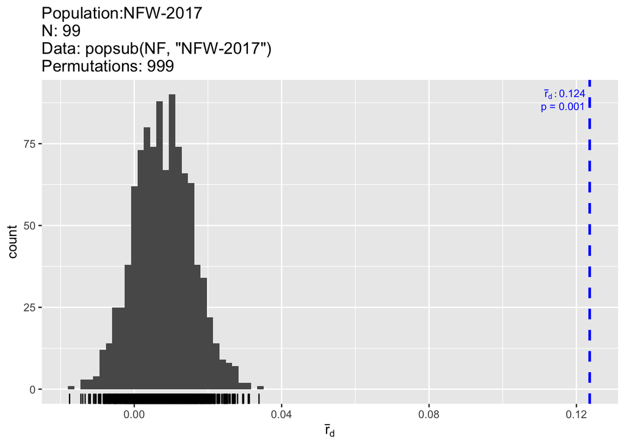

```r
NF.ia.W
```

```
##        Ia      p.Ia     rbarD      p.rD
## 0.6107414 0.0010000 0.1236043 0.0010000
```

Let’s try to figure out which alleles are linked via pairwise assessment:

```r
NF.W2017.pair <- pair.ia(popsub(NF, "NFW-2017"), quiet=F, plot=F)
NF.H2016.pair <- pair.ia(popsub(NF, "NFH-2016"), quiet=F, plot=F)
pair.range <- range(c(NF.W2017.pair, NF.H2016.pair), na.rm=TRUE)
```

## Check out the `pair.ia` results for each population. From the below plots, it looks like loci 13, 15 & 19 are possibly linked

```r
NF.W2017.pair
```

```
##                    Ia   rbarD
## Olur10:Olur11 -0.0104 -0.0107
## Olur10:Olur12  0.0109  0.0109
## Olur10:Olur13  0.0228  0.0228
## Olur10:Olur15  0.0143  0.0143
## Olur10:Olur19  0.0058  0.0058
## Olur11:Olur12 -0.0262 -0.0265
## Olur11:Olur13 -0.0372 -0.0386
## Olur11:Olur15 -0.0491 -0.0510
## Olur11:Olur19 -0.0453 -0.0461
## Olur12:Olur13 -0.0080 -0.0081
## Olur12:Olur15 -0.0040 -0.0041
## Olur12:Olur19  0.0072  0.0072
## Olur13:Olur15  0.7269  0.7269
## Olur13:Olur19  0.6486  0.6513
## Olur15:Olur19  0.8798  0.8833
```

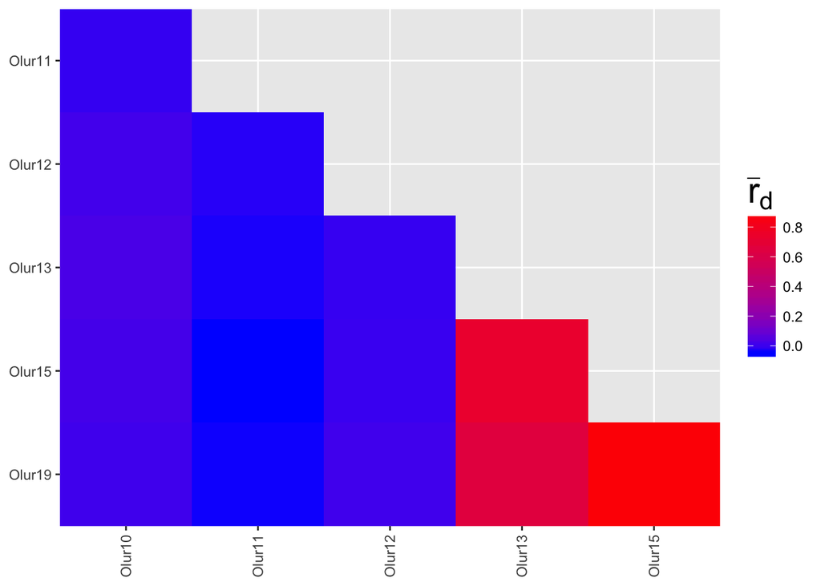

```r
plot(NF.W2017.pair, limits=pair.range, main="NFW-2017 Index of Association Pair Comparison")
```

```r
NF.H2016.pair
```

```
##                    Ia   rbarD
## Olur10:Olur11  0.0114  0.0119
## Olur10:Olur12  0.0185  0.0185
## Olur10:Olur13  0.0081  0.0083
## Olur10:Olur15 -0.0075 -0.0075
## Olur10:Olur19 -0.0082 -0.0084
## Olur11:Olur12 -0.0496 -0.0511
## Olur11:Olur13 -0.0085 -0.0086
## Olur11:Olur15 -0.0196 -0.0201
## Olur11:Olur19  0.0133  0.0134
## Olur12:Olur13 -0.0095 -0.0096
## Olur12:Olur15 -0.0407 -0.0407
## Olur12:Olur19  0.0113  0.0114
## Olur13:Olur15  0.6340  0.6390
## Olur13:Olur19  0.5312  0.5312
## Olur15:Olur19  0.6484  0.6534
```

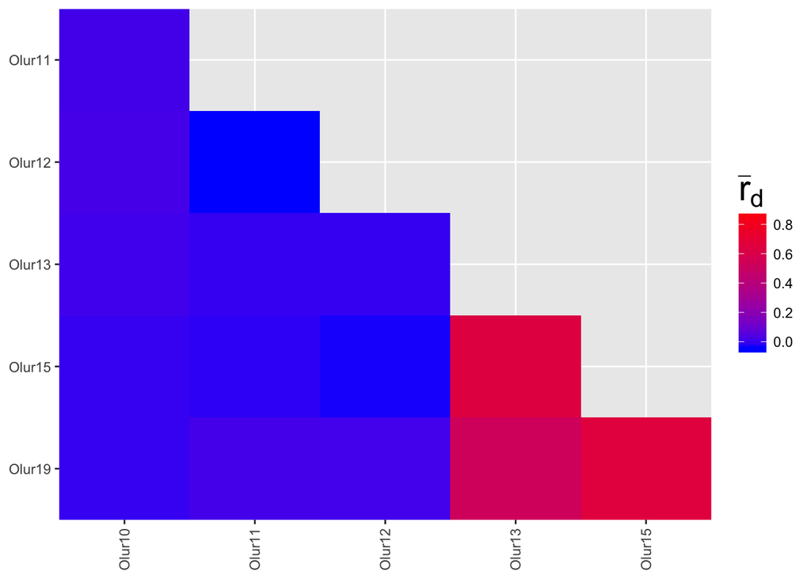

```r
plot(NF.H2016.pair, limits=pair.range, main="NFH-2016 Index of Association Pair Comparison")
```

# Review frequencies of each allele and plot frequency of hatchery vs. wild:

```r
NF.freq <- rraf(NF, by_pop=TRUE)
NF.freq.t <- t(NF.freq)
NF.freq.t
```

```
##               NFW-2017    NFH-2016
## Olur10.214 0.149484536 0.127551020
## Olur10.238 0.067010309 0.107142857
## Olur10.304 0.025773196 0.030612245
## Olur10.210 0.015463918 0.010000000
## Olur10.276 0.061855670 0.025510204
## Olur10.282 0.036082474 0.045918367
## Olur10.286 0.046391753 0.020408163
## Olur10.202 0.015463918 0.010204082
## Olur10.240 0.051546392 0.071428571
## Olur10.250 0.030927835 0.035714286
## Olur10.288 0.020618557 0.035714286
## Olur10.246 0.010309278 0.030612245
## Olur10.256 0.015463918 0.005102041
## Olur10.292 0.046391753 0.040816327
## Olur10.220 0.010309278 0.010204082
## Olur10.280 0.020618557 0.030612245
## Olur10.232 0.056701031 0.040816327
## Olur10.244 0.025773196 0.025510204
## Olur10.226 0.030927835 0.010204082
## Olur10.274 0.067010309 0.066326531
## Olur10.270 0.025773196 0.025510204
## Olur10.234 0.030927835 0.030612245
## Olur10.298 0.025773196 0.030612245
## Olur10.300 0.030927835 0.010204082
## Olur10.306 0.010309278 0.010000000
## Olur10.228 0.020618557 0.020408163
## Olur10.294 0.020618557 0.045918367
## Olur10.268 0.005154639 0.015306122
## Olur10.252 0.020618557 0.010204082
## Olur10.318 0.005154639 0.010000000
## Olur10.316 0.010101010 0.005102041
## Olur10.310 0.010101010 0.015306122
## Olur10.216 0.010101010 0.010204082
## Olur10.222 0.010101010 0.010204082
## Olur11.140 0.178947368 0.196808511
## Olur11.162 0.389473684 0.388297872
## Olur11.144 0.273684211 0.234042553
## Olur11.139 0.010526316 0.010638298
## Olur11.152 0.042105263 0.026595745
```

[output cut: 70 more lines]

```
## Olur19.209 0.041237113 0.046875000
## Olur19.261 0.072164948 0.057291667
## Olur19.245 0.067010309 0.062500000
## Olur19.265 0.051546392 0.109375000
## Olur19.213 0.036082474 0.026041667
## Olur19.221 0.072164948 0.072916667
## Olur19.257 0.103092784 0.083333333
## Olur19.217 0.020618557 0.046875000
## Olur19.253 0.082474227 0.098958333
## Olur19.237 0.046391753 0.041666667
## Olur19.241 0.036082474 0.010416667
## Olur19.273 0.020618557 0.020833333
## Olur19.281 0.005154639 0.005208333
## Olur19.277 0.005154639 0.010000000
## Olur19.269 0.005154639 0.015625000
```

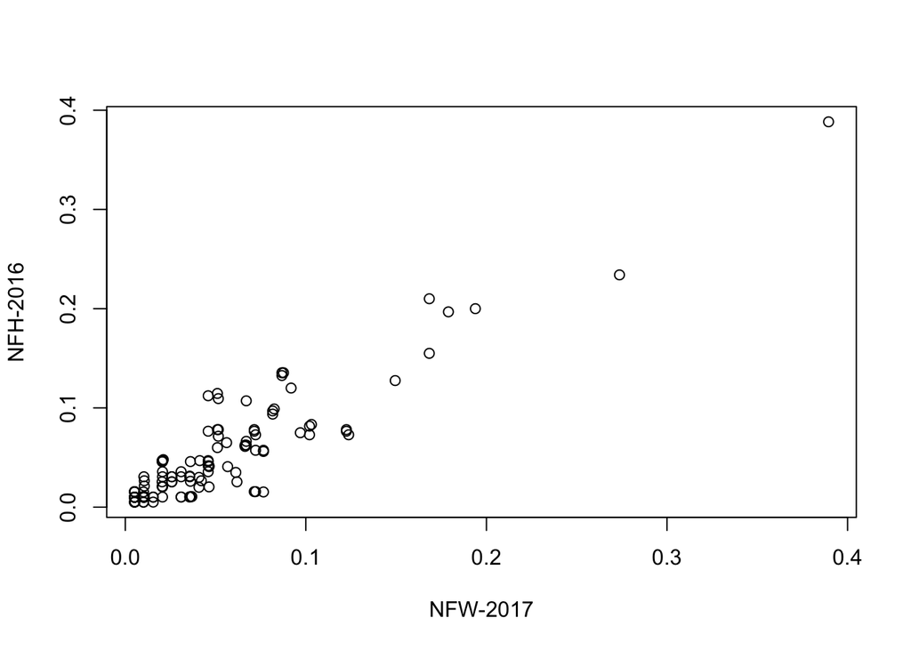

```r
plot(NF.freq.t)
```

## Testing out another tutorial & R package to generate statistics

Source: http://popgen.nescent.org/startMicrosatellite.html

```r
knitr::opts_chunk$set(library("adegenet"))
knitr::opts_chunk$set(library("pegas"))
```